# Final Project R reference 2

Ethan Rutledge

12/13/2021

```r
require(here)
delomys = data.frame(read.csv(here("data", "delomys.csv")))
summary(delomys)
```

```
##        X            genus             binomial           body_mass
##  Min.   :27526   Length:1585        Length:1585        Min.   :  5.00
##  1st Qu.:27950   Class :character   Class :character   1st Qu.: 35.00
##  Median :28348   Mode  :character   Mode  :character   Median : 43.00
##  Mean   :28371                                         Mean   : 44.06
##  3rd Qu.:28790                                         3rd Qu.: 54.00
##  Max.   :35552                                         Max.   :105.00
##   body_length        age                sex              longitude
##  Min.   : 49.0   Length:1585        Length:1585        Min.   :-49681671
##  1st Qu.:106.0   Class :character   Class :character   1st Qu.:      -50
##  Median :116.0   Mode  :character   Mode  :character   Median :      -50
##  Mean   :114.7                                         Mean   :   -62739
##  3rd Qu.:124.0                                         3rd Qu.:      -47
##  Max.   :265.0                                         Max.   :      -41
##     latitude            status
##  Min.   :-22383667   Length:1585
##  1st Qu.:      -29   Class :character
##  Median :      -29   Mode  :character
##  Mean   :   -28272
##  3rd Qu.:      -24
##  Max.   :      -20
```

```r
shapiro.test(delomys$body_mass)
```

```
##
##  Shapiro-Wilk normality test
##
## data:  delomys$body_mass
## W = 0.99506, p-value = 4.33e-05
```

```r
shapiro.test(delomys$body_length)
```

```
##
##  Shapiro-Wilk normality test
##
## data:  delomys$body_length
## W = 0.87609, p-value < 2.2e-16
```

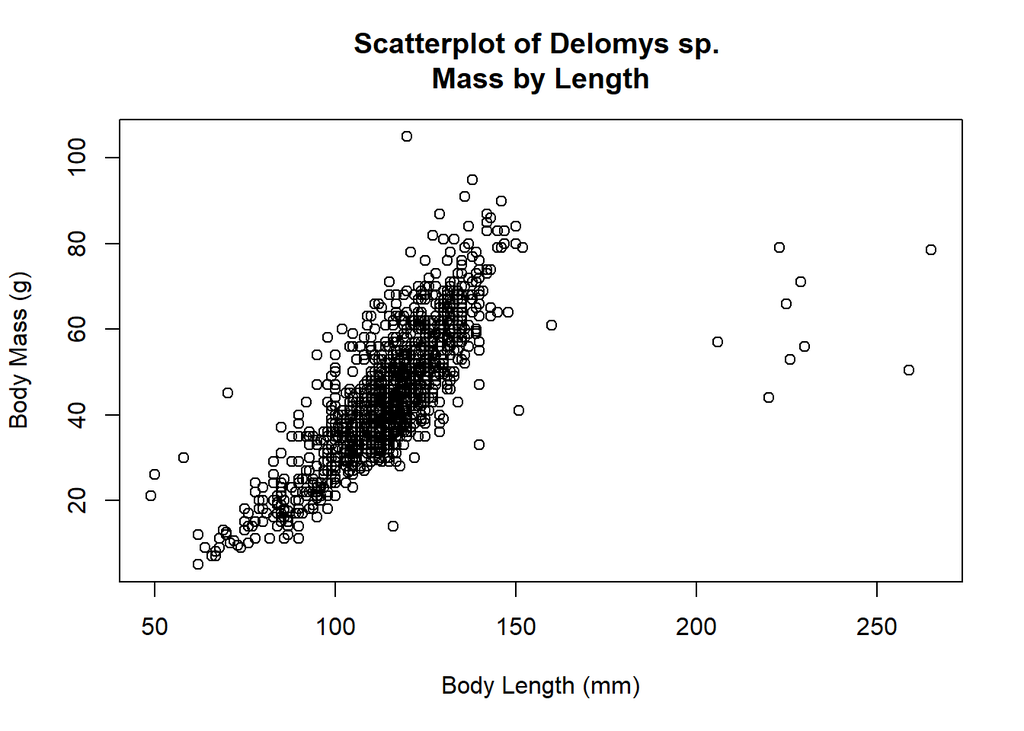

```r
##A scatterplot of body mass and body length
plot(body_mass ~ body_length, data = delomys, main = "Scatterplot of Delomys sp. \nMass by Length", ylab = "Body Mass (g)", xlab = "Body Length (mm)")
```

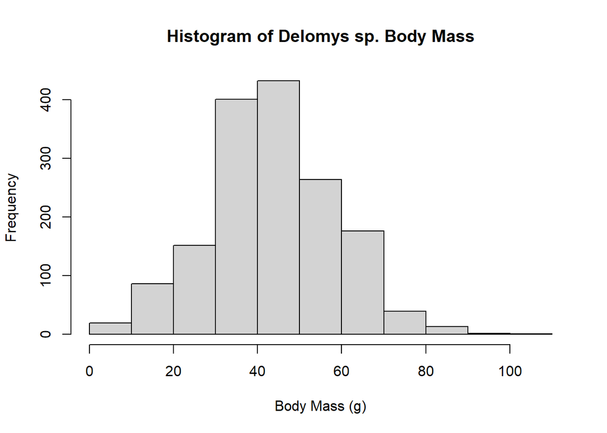

```r
##A histogram of body mass
hist(delomys$body_mass, main = "Histogram of Delomys sp. Body Mass", xlab = "Body Mass (g)", ylab = "Frequency")
```

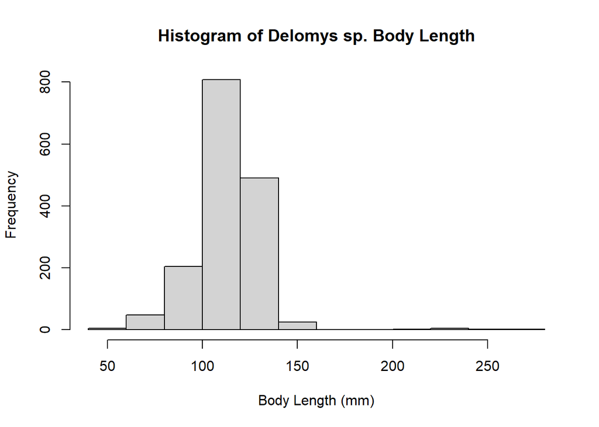

```r
##A histogram of body length
hist(delomys$body_length, main = "Histogram of Delomys sp. Body Length", ylab = "Frequency", xlab = "Body Length (mm)")
```

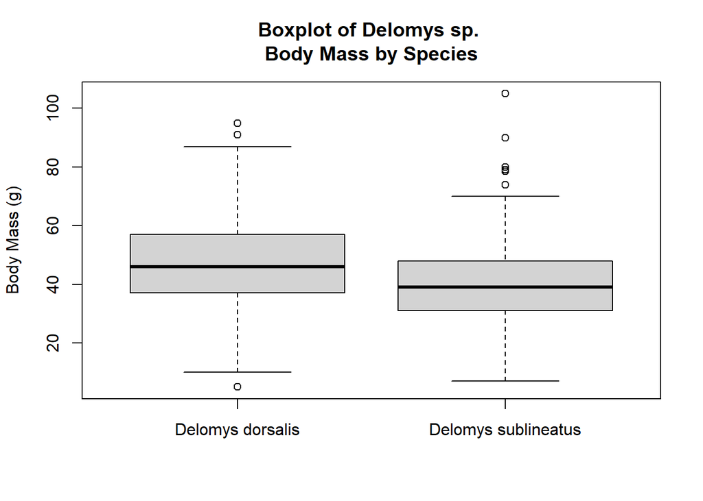

```r
##A conditional boxplot of body mass, conditioned on species (column binomial)
boxplot(body_mass ~ binomial, data = delomys, main = "Boxplot of Delomys sp. \nBody Mass by Species", ylab = "Body Mass (g)", xlab = "")
```

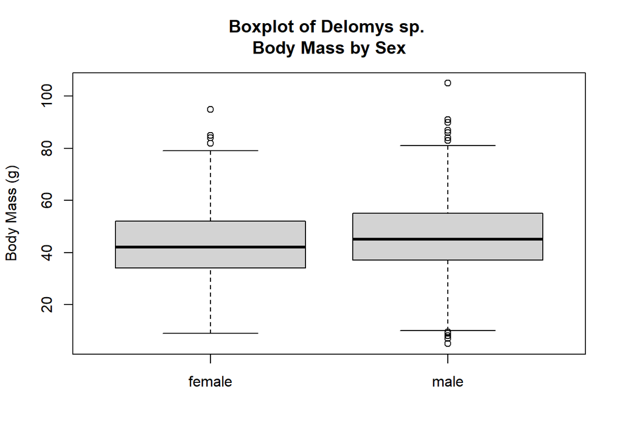

```r
##A conditional boxplot of body mass, conditioned on sex (column binomial)
boxplot(body_mass ~ sex, data = delomys, main = "Boxplot of Delomys sp. \nBody Mass by Sex", ylab = "Body Mass (g)", xlab = "")
```

[figure not shown]

```r
##A conditional boxplot of body mass, conditioned on both species and sex
boxplot(body_mass ~ binomial * sex, data = delomys, main = "Boxplot of Delomys sp. \nBody Mass by Species and Sex", ylab = "Body Mass (g)", xlab = "", las = 2, names = c("Delomys \ndorsalis \nMale", "Delomys \ndorsalis \nFemale", "Delomys \nsublineatus \nMale", "Delomys \nsublineatus \nFemale"), par(mar=c(6,4,4,3)))
```

Q1 (2 pts.): Qualitatively describe the relationship between body mass and length.  
Does the relationship seem linear, curved, nonexistent?

Q2 (2 pts.): Qualitatively describe the shapes of the histograms.  
Do the data appear normally-distributed? Explain why or why not.

Q3 (3 pts.): Using both the histograms and normality tests, do you think the (unconditioned) body masses and body length are normally-distributed?  
Contrast your visual assessment of normality to the results of the numerical normality tests.

According to the normality tests, they are not normal. Both the histograms and the numerical tests indicate that mass is less non-normal than length, though both are still not normally distributed.

Q4 (2 pts.): Examine the conditional boxplots. Describe any graphical evidence you see for body mass differences based on species and/or sex.

There appears to be slight differences in body mass between species, dorsalis being larger, but there is much overlap in the boxplots. There appears to be differences between sex for both species, males being larger.

```r
##Model 1: simple linear regression body_length ~ body_mass
fit_1 = lm(body_length ~ body_mass, data = delomys)
fit_1
```

```
##
## Call:
## lm(formula = body_length ~ body_mass, data = delomys)
##
## Coefficients:
## (Intercept)    body_mass
##     76.1247       0.8755
```

```r
##Model 2: 1-way ANOVA body_mass ~ sex
fit_2 = lm(body_mass ~ sex, data = delomys)
anova(fit_2)
```

```
## Analysis of Variance Table
##
## Response: body_mass
##             Df Sum Sq Mean Sq F value    Pr(>F)
## sex          1   3062 3061.68  13.943 0.0001951 ***
## Residuals 1578 346507  219.59
## ---
## Signif. codes:  0 '***' 0.001 '**' 0.01 '*' 0.05 '.' 0.1 ' ' 1
```

```r
##Model 3: 1-way ANOVA body_mass ~ binomial
fit_3 = lm(body_mass ~ binomial, data = delomys)
anova(fit_3)
```

```
## Analysis of Variance Table
##
## Response: body_mass
##             Df Sum Sq Mean Sq F value    Pr(>F)
## binomial     1  21290 21289.7  102.08 < 2.2e-16 ***
## Residuals 1583 330164   208.6
## ---
## Signif. codes:  0 '***' 0.001 '**' 0.01 '*' 0.05 '.' 0.1 ' ' 1
```

```r
##Model 4: 2-way additive ANOVA body_mass ~ sex + binomial
fit_4 = lm(body_mass ~ sex + binomial, data = delomys)
anova(fit_4)
```

```
## Analysis of Variance Table
##
## Response: body_mass
##             Df Sum Sq Mean Sq F value    Pr(>F)
## sex          1   3062  3061.7  14.958 0.0001144 ***
## binomial     1  23727 23727.1 115.923 < 2.2e-16 ***
## Residuals 1577 322780   204.7
## ---
## Signif. codes:  0 '***' 0.001 '**' 0.01 '*' 0.05 '.' 0.1 ' ' 1
```

```r
##Model 5: 2-way factorial ANOVA body_mass ~ sex * binomial
fit_5 = lm(body_mass ~ sex * binomial, data = delomys)
anova(fit_5)
```

```
## Analysis of Variance Table
##
## Response: body_mass
##                Df Sum Sq Mean Sq  F value    Pr(>F)
## sex             1   3062  3061.7  14.9489  0.000115 ***
## binomial        1  23727 23727.1 115.8500 < 2.2e-16 ***
## sex:binomial    1      1     0.8   0.0039  0.950442
## Residuals    1576 322779   204.8
## ---
## Signif. codes:  0 '***' 0.001 '**' 0.01 '*' 0.05 '.' 0.1 ' ' 1
```

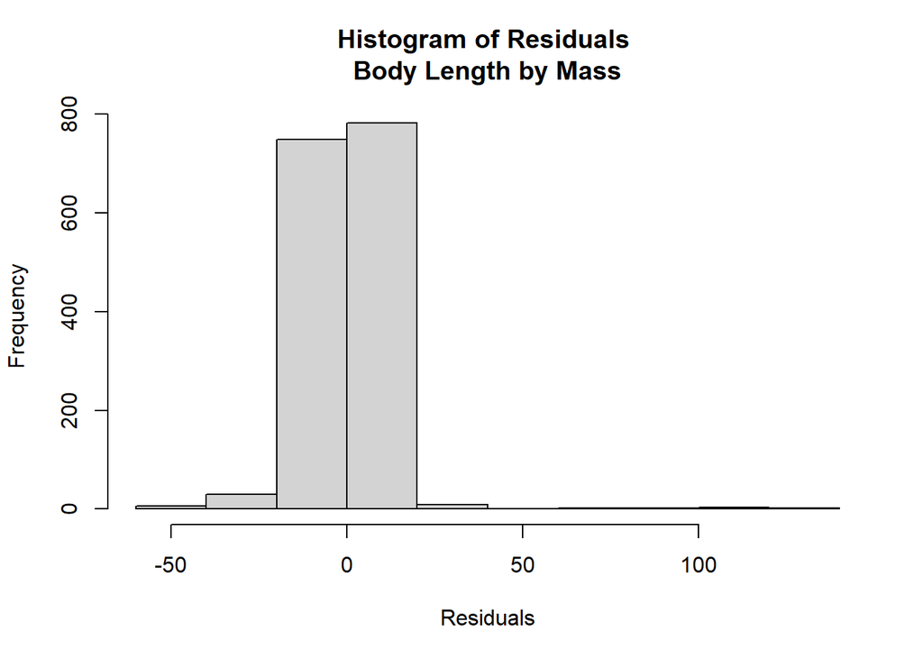

```r
##Use a code chunk to create histograms of the residuals of each of the 5 models.
hist(residuals(fit_1), main = "Histogram of Residuals \nBody Length by Mass", ylab = "Frequency", xlab = "Residuals")
```

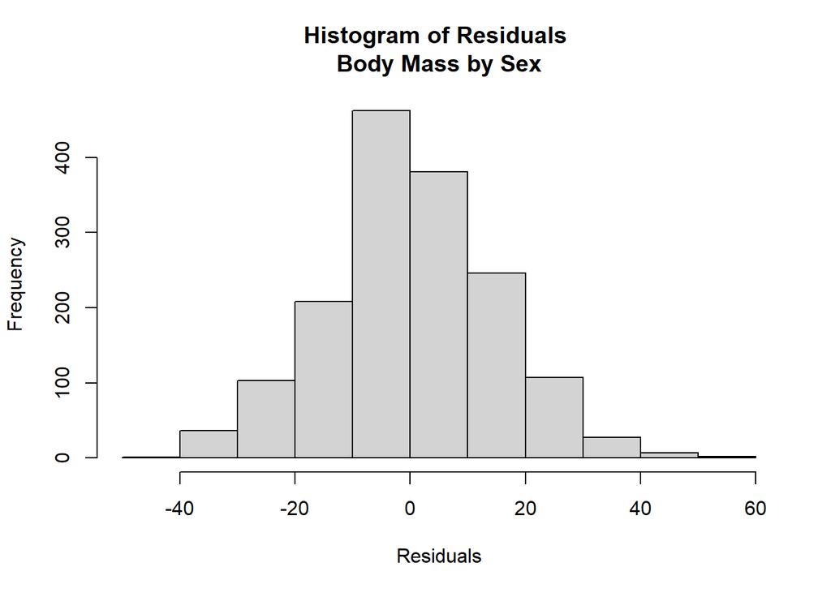

```r
##Use a code chunk to create histograms of the residuals of each of the 5 models.
hist(residuals(fit_2), main = "Histogram of Residuals \nBody Mass by Sex", ylab = "Frequency", xlab = "Residuals")
```

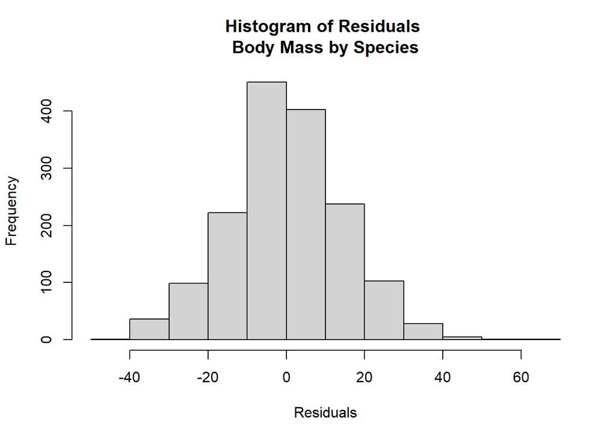

```r
##Use a code chunk to create histograms of the residuals of each of the 5 models.
hist(residuals(fit_3), main = "Histogram of Residuals \nBody Mass by Species", ylab = "Frequency", xlab = "Residuals")
```

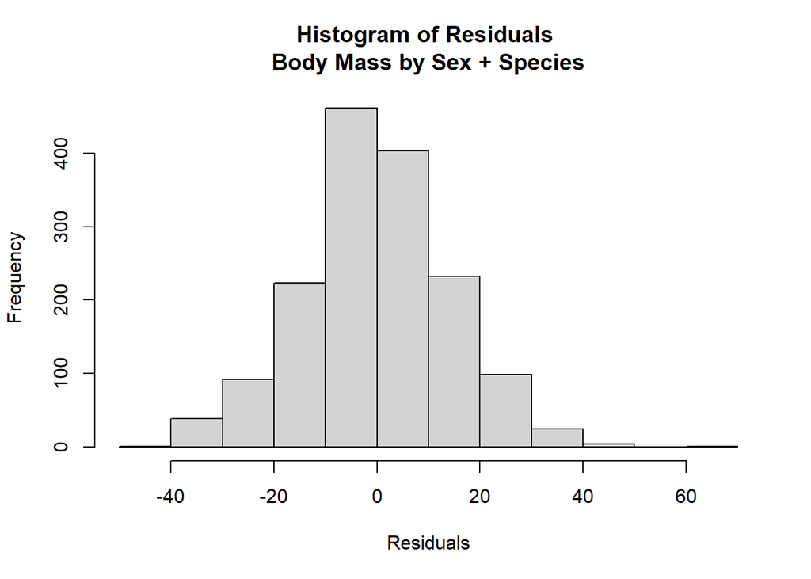

```r
##Use a code chunk to create histograms of the residuals of each of the 5 models.
hist(residuals(fit_4), main = "Histogram of Residuals \nBody Mass by Sex + Species", ylab = "Frequency", xlab = "Residuals")
```

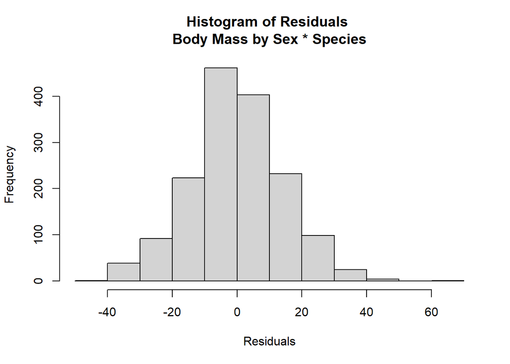

```r
##Use a code chunk to create histograms of the residuals of each of the 5 models.
hist(residuals(fit_5), main = "Histogram of Residuals \nBody Mass by Sex * Species", ylab = "Frequency", xlab = "Residuals")
```

```r
##Use shapiro.test() on each model to test the null hypothesis that the residuals are drawn from a normally-distributed population.
shapiro.test(fit_1$residuals)
```

```
##
##  Shapiro-Wilk normality test
##
## data:  fit_1$residuals
## W = 0.73462, p-value < 2.2e-16
```

```r
shapiro.test(fit_2$residuals)
```

```
##
##  Shapiro-Wilk normality test
##
## data:  fit_2$residuals
## W = 0.99563, p-value = 0.0001541
```

```r
shapiro.test(fit_3$residuals)
```

```
##
##  Shapiro-Wilk normality test
##
## data:  fit_3$residuals
## W = 0.99535, p-value = 8.103e-05
```

```r
shapiro.test(fit_4$residuals)
```

```
##
##  Shapiro-Wilk normality test
##
## data:  fit_4$residuals
## W = 0.99525, p-value = 6.805e-05
```

```r
shapiro.test(fit_5$residuals)
```

```
##
##  Shapiro-Wilk normality test
##
## data:  fit_5$residuals
## W = 0.99526, p-value = 6.816e-05
```

Q5 (2 pts.): What do you conclude about residual normality based on the numerical and graphical diagnostics?

Ultimately, they are not normal distributions or residuals. Though the graphs could be misleading.

Q6 (1 pt.): Are violations of the normality assumption equally severe for all the models?

No, it often depends on the extent of this violation. The first model is worse than the rest.

```r
##Print the model coefficient table using summary()
summary(fit_1)
```

```
##
## Call:
## lm(formula = body_length ~ body_mass, data = delomys)
##
## Residuals:
##     Min      1Q  Median      3Q     Max
## -48.888  -5.398   0.104   4.859 138.663
##
## Coefficients:
##             Estimate Std. Error t value Pr(>|t|)
## (Intercept) 76.12466    0.91581   83.12   <2e-16 ***
## body_mass    0.87550    0.01969   44.46   <2e-16 ***
## ---
## Signif. codes:  0 '***' 0.001 '**' 0.01 '*' 0.05 '.' 0.1 ' ' 1
##
## Residual standard error: 11.67 on 1583 degrees of freedom
## Multiple R-squared:  0.5553, Adjusted R-squared:  0.5551
## F-statistic:  1977 on 1 and 1583 DF,  p-value: < 2.2e-16
```

Q7 (2 pts.): What is the magnitude of the mass/length relationship?

.88

Q8 (2 pts.): What is the expected body length of an animal that weighs 100g?

basecase + body_mass x 100  
76.12 + (.88 x 100) = 164.12

Q9 (2 pts.): What is the expected body length of an animal that weighs 0g?

76.12 + (.88 x 0) = 76.12

```r
##Print the model coefficient tables for each of the body mass model fits.
summary(fit_2)
```

```
##
## Call:
## lm(formula = body_mass ~ sex, data = delomys)
##
## Residuals:
##     Min      1Q  Median      3Q     Max
## -40.496  -8.711  -0.496   9.504  59.504
##
## Coefficients:
##             Estimate Std. Error t value Pr(>|t|)
## (Intercept)  42.7115     0.5289  80.756  < 2e-16 ***
## sexmale       2.7841     0.7456   3.734 0.000195 ***
## ---
## Signif. codes:  0 '***' 0.001 '**' 0.01 '*' 0.05 '.' 0.1 ' ' 1
##
## Residual standard error: 14.82 on 1578 degrees of freedom
##   (5 observations deleted due to missingness)
## Multiple R-squared:  0.008758,   Adjusted R-squared:  0.00813
## F-statistic: 13.94 on 1 and 1578 DF,  p-value: 0.0001951
```

```r
summary(fit_3)
```

```
##
## Call:
## lm(formula = body_mass ~ binomial, data = delomys)
##
## Residuals:
##     Min      1Q  Median      3Q     Max
## -41.752  -9.069  -0.069   9.248  65.931
##
## Coefficients:
##                             Estimate Std. Error t value Pr(>|t|)
## (Intercept)                  46.7524     0.4500   103.9   <2e-16 ***
## binomialDelomys sublineatus  -7.6831     0.7605   -10.1   <2e-16 ***
## ---
## Signif. codes:  0 '***' 0.001 '**' 0.01 '*' 0.05 '.' 0.1 ' ' 1
##
## Residual standard error: 14.44 on 1583 degrees of freedom
## Multiple R-squared:  0.06058,    Adjusted R-squared:  0.05998
## F-statistic: 102.1 on 1 and 1583 DF,  p-value: < 2.2e-16
```

```r
summary(fit_4)
```

```
##
## Call:
## lm(formula = body_mass ~ sex + binomial, data = delomys)
##
## Residuals:
##     Min      1Q  Median      3Q     Max
## -43.866  -8.866  -0.672   8.930  64.328
##
## Coefficients:
##                             Estimate Std. Error t value Pr(>|t|)
## (Intercept)                  45.0704     0.5556  81.114  < 2e-16 ***
## sexmale                       3.7954     0.7260   5.228 1.94e-07 ***
## binomialDelomys sublineatus  -8.1935     0.7610 -10.767  < 2e-16 ***
## ---
## Signif. codes:  0 '***' 0.001 '**' 0.01 '*' 0.05 '.' 0.1 ' ' 1
##
## Residual standard error: 14.31 on 1577 degrees of freedom
##   (5 observations deleted due to missingness)
## Multiple R-squared:  0.07663,    Adjusted R-squared:  0.07546
## F-statistic: 65.44 on 2 and 1577 DF,  p-value: < 2.2e-16
```

```r
summary(fit_5)
```

```
##
## Call:
## lm(formula = body_mass ~ sex * binomial, data = delomys)
##
## Residuals:
##     Min      1Q  Median      3Q     Max
## -43.884  -8.884  -0.647   8.945  64.353
##
## Coefficients:
##                                     Estimate Std. Error t value Pr(>|t|)
## (Intercept)                         45.05546    0.60530  74.435  < 2e-16 ***
## sexmale                              3.82809    0.89667   4.269 2.08e-05 ***
## binomialDelomys sublineatus         -8.14174    1.12810  -7.217 8.22e-13 ***
## sexmale:binomialDelomys sublineatus -0.09502    1.52859  -0.062     0.95
## ---
## Signif. codes:  0 '***' 0.001 '**' 0.01 '*' 0.05 '.' 0.1 ' ' 1
##
## Residual standard error: 14.31 on 1576 degrees of freedom
##   (5 observations deleted due to missingness)
## Multiple R-squared:  0.07664,    Adjusted R-squared:  0.07488
## F-statistic:  43.6 on 3 and 1576 DF,  p-value: < 2.2e-16
```

Q10 (1 pt.): What is the base level for sex?

42.7115

Q11 (1 pt.): What is the base level for binomial?

46.7524

Q12 (1 pt.): Which sex is heavier?

Male

Q13 (1 pt.): Which species is heavier?

Delomys dorsalis

```r
##Print the ANOVA tables for each of the body mass models
anova(fit_2)
```

```
## Analysis of Variance Table
##
## Response: body_mass
##             Df Sum Sq Mean Sq F value    Pr(>F)
## sex          1   3062 3061.68  13.943 0.0001951 ***
## Residuals 1578 346507  219.59
## ---
## Signif. codes:  0 '***' 0.001 '**' 0.01 '*' 0.05 '.' 0.1 ' ' 1
```

```r
anova(fit_3)
```

```
## Analysis of Variance Table
##
## Response: body_mass
##             Df Sum Sq Mean Sq F value    Pr(>F)
## binomial     1  21290 21289.7  102.08 < 2.2e-16 ***
## Residuals 1583 330164   208.6
## ---
## Signif. codes:  0 '***' 0.001 '**' 0.01 '*' 0.05 '.' 0.1 ' ' 1
```

```r
anova(fit_4)
```

```
## Analysis of Variance Table
##
## Response: body_mass
##             Df Sum Sq Mean Sq F value    Pr(>F)
## sex          1   3062  3061.7  14.958 0.0001144 ***
## binomial     1  23727 23727.1 115.923 < 2.2e-16 ***
## Residuals 1577 322780   204.7
## ---
## Signif. codes:  0 '***' 0.001 '**' 0.01 '*' 0.05 '.' 0.1 ' ' 1
```

```r
anova(fit_5)
```

```
## Analysis of Variance Table
##
## Response: body_mass
##                Df Sum Sq Mean Sq  F value    Pr(>F)
## sex             1   3062  3061.7  14.9489  0.000115 ***
## binomial        1  23727 23727.1 115.8500 < 2.2e-16 ***
## sex:binomial    1      1     0.8   0.0039  0.950442
## Residuals    1576 322779   204.8
## ---
## Signif. codes:  0 '***' 0.001 '**' 0.01 '*' 0.05 '.' 0.1 ' ' 1
```

Q14 (1 pt.): Are sex and species significant predictors for body mass?

Yes, they alone are both significant predictors for body mass.

Q15 (1 pt.): Is there a significant interaction?

No, there is not a significant interaction between sex and species.

Q16 (2 pts.): How does the significance (as measured by p-value) of either of the main effects (sex and species) differ between the single-predictor models, the additive model, and the interactive model?

The species pvalues do not change at all for any of the 3 models. The sex pvalues change slightly but not in overall significance. The sex pvalue is slightly more significant in the additive and interactive model.

```r
##Create a code chunk that calculates the AIC values for each of the body mass models.
AIC(fit_2, fit_3, fit_4, fit_5)
```

```
##       df      AIC
## fit_2  3 13006.80
## fit_3  3 12966.36
## fit_4  4 12896.73
## fit_5  5 12898.72
```

Q17 (1 pt.): Which two models have the lowest AIC?

fit_4 and fit_5

Q18 (4 pts.): Which of the two models with lowest AIC scores would you select? Explain your decision based on model fit and the complexity/understanding tradeoff.

I would select model fit_5, the interactive model. Both models display significant predictors of body mass, however the additive model leaves out important information regarding the interaction. It would be safe to use the additive model,it would even make more sense to use it, but I also think that it’s important to get the info out there that the interaction is not significant,just for better communication of information to the scientific community.